# Example no.2 Webscraping

Fernando Hernández Esquivel

19 de mayo de 2019

El siguiente ejemplo es sobre un artículo titulado “Physicists reverse time using quantum computer” de la página de divulgación científica Physics.org, del cual se realizará un análisis de sentimientos sobre lo comentarios de los usuarios registrados a dicha página. Para ir al artículo presiona el siguiente [enlace](https://phys.org/news/2019-03-physicists-reverse-quantum.html)

```r
library(dplyr)
library(syuzhet)
library(rvest)
library(stringr)
library(XML)
library(tm)
```

```r
library(wordcloud)
library(RColorBrewer)
```

Una vez caragadas las paqueterias se continua cargando la página y extrayendo los nodos de interés

```r
art<-read_html(x="https://phys.org/news/2019-03-physicists-reverse-quantum.html")
# Nodos
usuario<-art%>%html_nodes("div [class=comment-text]")%>%html_text()
head(usuario,3)
```

```
## [1] " Researchers . . . returned the state of a quantum computer a fraction of a second into the past.  A special program modifies the state of the quantum computer in such a way that it would then evolve \"backwards,\" from chaos toward order. Sounds more like a clever reset than time travel int…
## [2] "If running a program to put things back the way they were is time travel, then so is cleaning my room. I think it is irresponsible and dishonest to describe the execution of this program as 'reversing time.' And scientists wonder why we don't take their word seriously? It is much more easily…
## [3] " And scientists wonder why we don't take their word seriously? Homebrook, you are a Scumbag Denier working the, \"more CO2 is a good thing\" angle, so your motives for commenting are untrustworthy.  For example, in this case, one exaggerated claim, from Russia et al. no less, and you conclud…
```

Ya que se han extraído los comentarios, se hace un breve análisis

```r
# Se cuentan las palabras totales de cada comentario
str_count(usuario, "\\w+")
```

```
##  [1]  52 117  68  62  21  64   5  37 102 158   4  74  19 159 143  93  15
## [18]  63  16 146 120  30 118  38  13   5  11  84  44  40  90 150 141  81
## [35] 153 125 178 112 161  57  13  39 173  34  96  97 115 160  21 185  57
## [52]  19  79  65  10  55 142 117  32 178  49  59  27 168  25 165 176  89
## [69]  99  60  80 157 177 160  23  38  49  74  58 175 157 180   9  94 121
## [86]  80
```

```r
# Se busca el comentario con el mínimo de palabras empleadas
min(str_count(usuario, "\\w+"))
```

```
## [1] 4
```

```r
# Se busca el comentario con el máximo de palabras empleadas
max(str_count(usuario, "\\w+"))
```

```
## [1] 185
```

```r
# Se calcula la media de palabras usadas en los comentarios
mean(str_count(usuario, "\\w+"))
```

```
## [1] 86.10465
```

```r
# Se visualizan los comentarios con mayor y menor número de palabras
usuario[str_count(usuario, "\\w+")==4]
```

```
## [1] "somebody, alert cher STAT!!"
```

```r
usuario[str_count(usuario, "\\w+")==185]
```

```
## [1] " When an electron goes to it's PastIf an electron goes back to it's pastgoes back 54 hours hence into it's pastwhere does everyone thinks it goeswell firstly, where was it 54 hours agoit was where the Earth was 54 hours ago in its orbit round the Sunif everyone wants to know where this elect…
```

Ahora se aplica el análisis de sentimientos a los comentarios

```r
comentarios<-iconv(usuario,to='UTF-8')
# se obtienen los "scores" de los comentarios
scores<-get_nrc_sentiment(comentarios)
head(scores)
```

```
##   anger anticipation disgust fear joy sadness surprise trust negative
## 1     1            1       1    1   1       1        0     0        2
## 2     3            3       3    3   1       6        0     5        6
## 3     1            1       0    1   1       1        1     3        3
## 4     1            1       0    1   0       0        0     3        1
## 5     0            1       0    0   0       0        1     2        0
## 6     0            0       0    0   0       0        0     1        0
##   positive
## 1        2
## 2        6
## 3        4
## 4        2
## 5        1
## 6        3
```

Se aplica un “summary” a los “scores”

```r
summary(scores)
```

```
##      anger         anticipation      disgust            fear
##  Min.   :0.0000   Min.   :0.000   Min.   :0.0000   Min.   :0.0000
##  1st Qu.:0.0000   1st Qu.:1.000   1st Qu.:0.0000   1st Qu.:0.0000
##  Median :0.0000   Median :1.000   Median :0.0000   Median :0.0000
##  Mean   :0.6977   Mean   :1.756   Mean   :0.5698   Mean   :0.7093
##  3rd Qu.:1.0000   3rd Qu.:3.000   3rd Qu.:1.0000   3rd Qu.:1.0000
##  Max.   :5.0000   Max.   :8.000   Max.   :5.0000   Max.   :5.0000
##       joy            sadness          surprise          trust
##  Min.   :0.0000   Min.   :0.0000   Min.   :0.0000   Min.   :0.000
##  1st Qu.:0.0000   1st Qu.:0.0000   1st Qu.:0.0000   1st Qu.:0.000
##  Median :0.0000   Median :0.0000   Median :0.0000   Median :1.500
##  Mean   :0.6163   Mean   :0.6047   Mean   :0.5116   Mean   :1.895
##  3rd Qu.:1.0000   3rd Qu.:1.0000   3rd Qu.:1.0000   3rd Qu.:3.000
##  Max.   :3.0000   Max.   :6.0000   Max.   :4.0000   Max.   :8.000
##     negative         positive
##  Min.   : 0.000   Min.   :0.000
##  1st Qu.: 0.000   1st Qu.:1.000
##  Median : 1.500   Median :2.000
##  Mean   : 2.035   Mean   :2.779
##  3rd Qu.: 3.000   3rd Qu.:4.000
##  Max.   :14.000   Max.   :9.000
```

Se revisan los comentarios que se han calificado como muy negativos y muy positivos

```r
# negative comments
Nc<-subset(comentarios,subset=scores$negative>6)
Nc
```

```
## [1] "*sigh* Here we go again; inept 'science writers' and hack 'paper writers' misrepresenting reality for the sake of (unearned) wages/citations/grants etc from equally disingenuous 'peers'.When will this silliness end?The stupid analogy of \"playing back a film of colliding billiard balls\" IGN…
## [2] "@rrwillsj.   well rc, since you insist on bringing up the subject? You seem quite addicted to these \"stupid analogy\" you are always whining about. Since you do not approve of any research results that do not match your delusions of pompous pedagogy? What masochistic fixation keeps pulling …
```

```r
# positive comments
Pc<-subset(comentarios,subset=scores$positive>6)
Pc
```

```
## [1] "@Mark Thomas, Nice ad-hominem attack! Very persuasive, I am sure, and fair-minded too. But what about the substance of my comment, that the article greatly exaggerated the significance of their findings.Originated from Russia, true, but published in Scientific Reports, a supposedly reputable…
## [2] "@torbjorn, the FT says the 2LOT applies less and less as the volume under consideration and the time for it to evolve becomes smaller. I think this theorem is insufficiently understood. It is very firmly based and very strong supporting evidence for it has been produced in the lab, more than…
## [3] "Incidentally, space also is a symmetry of physics that has a corresponding conservation law under Noether's theorem. The complement to symmetry over space is conservation of momentum. Now you explain why. You can't, of course, any more than you can explain why conservation of energy is relat…
## [4] "@Da Schneib '....There's still something we don't yet quite get.' and other comments. Yes I do tend to agree with you in as much as a layperson could. In a simplistic way (I admit the danger in doing this) I see the so called 'arrow of time' as continuous change. We see, hear and feel change…
## [5] "   this makes no sense at allelectron is moving in space only and time is the mathematical parameter of its motion https://phys.org/...ace.html   AmritSorliI agree with you what that link says doesn't make much sense. I think the main reason why it doesn't make much sense is because they are…
## [6] " Surveillance_Egg_UnitWhat does \"what is time made of?\" mean?Its a completely gibberish nonsense question, like \"what is a series of events made of?\" or \"what is beauty made of? or \"what is the mathematical constant Pi made of?\" etc.Not everything that exists can be said to be \"made …
```

Y se crea una nueva categoría para ver si existen comentarios neutrales, y se visualiza

```r
scores$neutral<-ifelse(scores$negative+scores$positive==0,1,0)
Nc<-subset(comentarios,subset=scores$neutral==1)
Nc
```

```
##  [1] "These idiots are NOT scientists!"
##  [2] "somebody, alert cher STAT!!"
##  [3] "https://medicalxp...ies.htmlWhat is referred to as \"time\" lives ONLY in the human brain."
##  [4] "Perhaps Dark Matter is just \"smeared\" across time, and we should be looking for it yesterday."
##  [5] " Perhaps Dark Matter is just \"smeared\" across time, and we should be looking for it yesterday. And how do you propose to get back to yesterday to look for DM?"
##  [6] "https://en.wikipe..._of_timeJust sayin'. "
##  [7] "When an electron goes to it's PastIf an electron goes back to it's pastgoes back 54 hours henceinto it's pastwhere does everyone thinks it goeswellfirstly, where was it 54 hours agoit was where the Earthwas 54 hours agoin its orbit round the Sunif everyone wants to know where this electron …
##  [8] " When an electron goes to it's Past Extraneous apostrophe. Lern to Inglish."
##  [9] "The same thing as space. What's space made of? "
## [10] "Predicting the future is exactly science. That's how a hypothesis becomes a theory: predicting future events, in detail. Teh stoopit, it burnz. "
```

Finalmente, se grafícan los comentarios

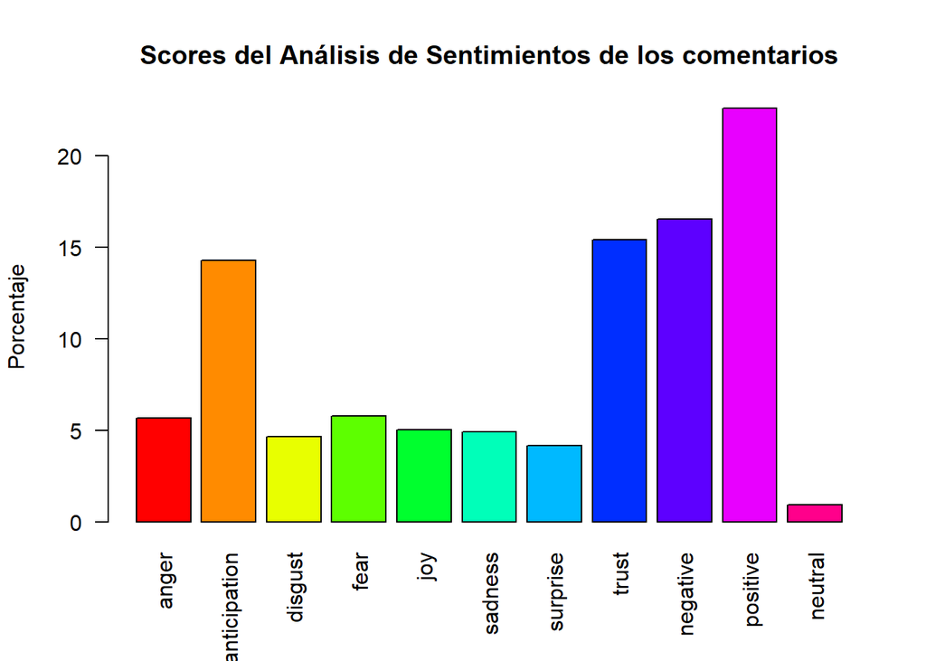

```r
barplot(100*colSums(scores)/sum(scores),las=2,col=rainbow(11),ylab="Porcentaje",
        main="Scores del Análisis de Sentimientos de los comentarios")
```

Aunque al aplicar el “summary” a las categorías se observo que la categoría “Negative” obtuvo los valores más altos, al ponderar y graficar, fueron los comentarios positivos lo que obtuvieron el mayor porcentaje.

Ahora se continua transformando nuestro vector en un corpus para poder ser analizado

```r
corp<-Corpus(VectorSource(usuario))
# Se quitan los signos de puntuación
corp<-tm_map(corp, removePunctuation)
# Se convierten en minúsculas todas las palabras
corp<-tm_map(corp, content_transformer(tolower))
# Se borran los números
corp<-tm_map(corp, removeNumbers)
# Se quitan las palabras que carecen de un significado importante en un texto
corp<-tm_map(corp, function(x)removeWords(x,stopwords("English")))
```

Una vez creado el corpus se procede a la creación de la “Term-document matrix” que es la matriz donde se encuentra la información de la repetición y empleo de cada palabra en el corpus

```r
term.matrix<-TermDocumentMatrix(corp)
term.matrix<-as.matrix(term.matrix)
head(term.matrix)
```

```
##            Docs
## Terms       1 2 3 4 5 6 7 8 9 10 11 12 13 14 15 16 17 18 19 20 21 22 23 24
##   backwards 1 0 0 0 0 0 0 0 1  0  0  0  0  0  0  0  0  0  0  0  0  0  0  0
##   chaos     1 0 0 0 0 0 0 0 0  0  0  0  0  0  0  0  0  0  0  0  0  0  0  0
##   clever    1 0 0 0 0 0 0 0 0  0  0  0  0  0  0  0  0  0  0  0  0  0  0  0
##   computer  2 0 0 0 0 1 0 0 0  0  0  0  0  0  1  0  0  0  0  0  0  0  1  0
##   evolve    1 0 0 0 0 0 0 0 0  0  0  0  0  0  0  0  0  0  0  0  1  0  0  0
##   fraction  1 0 0 0 0 0 0 0 0  0  0  0  0  0  0  0  0  0  0  0  0  0  0  0
##            Docs
## Terms       25 26 27 28 29 30 31 32 33 34 35 36 37 38 39 40 41 42 43 44 45
##   backwards  0  0  0  0  0  0  0  0  0  0  0  0  0  0  0  0  0  0  0  0  0
##   chaos      0  0  0  0  0  0  0  0  0  0  0  0  0  0  0  0  0  0  0  0  0
##   clever     0  0  0  0  0  0  0  0  0  0  0  0  0  0  0  0  0  0  0  0  0
##   computer   0  0  0  1  0  0  0  0  0  0  0  1  1  0  0  0  0  0  0  0  0
##   evolve     0  0  0  0  0  0  0  0  0  0  0  0  0  0  1  0  0  0  0  0  0
##   fraction   0  0  0  0  0  0  0  0  0  0  0  0  0  0  0  0  0  0  0  0  0
##            Docs
## Terms       46 47 48 49 50 51 52 53 54 55 56 57 58 59 60 61 62 63 64 65 66
##   backwards  0  0  0  0  0  0  0  0  0  0  0  0  0  0  0  0  0  0  1  0  0
##   chaos      0  0  4  0  0  0  0  0  0  0  0  0  0  0  0  0  0  0  1  0  0
##   clever     0  0  0  0  0  0  0  0  0  0  0  0  0  0  0  0  0  0  1  0  0
##   computer   0  0  0  0  0  0  0  0  0  0  0  0  0  0  0  0  0  0  2  0  0
##   evolve     0  0  0  0  0  0  0  0  0  0  0  0  0  0  0  0  0  0  1  0  0
##   fraction   0  0  0  0  0  0  0  0  0  0  0  0  0  0  0  0  0  0  1  0  0
##            Docs
## Terms       67 68 69 70 71 72 73 74 75 76 77 78 79 80 81 82 83 84 85 86
##   backwards  0  0  0  0  1  0  0  0  0  0  0  0  0  0  0  0  1  0  0  1
##   chaos      0  0  0  0  0  0  0  0  0  0  0  0  0  0  0  0  0  0  0  0
##   clever     0  0  0  0  0  0  0  0  0  0  0  0  0  0  0  0  0  0  0  0
##   computer   0  0  0  0  0  0  0  0  0  0  0  0  0  0  0  0  0  0  0  0
##   evolve     0  0  0  0  0  0  0  0  0  0  0  0  0  0  0  0  0  0  0  0
##   fraction   0  0  0  0  0  0  0  0  0  0  0  0  0  0  0  0  0  0  0  0
```

Aquí se crea una tabla de frecuencias de cada una de las palabras encontradas en el corpus

```r
# Se cuentan descendentemente el número de palabras
word_freqs<-sort(rowSums(term.matrix),decreasing=TRUE)
# Se crea la tabla
dm<-data.frame(word=names(word_freqs),freq=word_freqs)
head(dm,10)
```

```
##            word freq
## time       time  146
## space     space   56
## hours     hours   45
## entropy entropy   31
## quantum quantum   28
## will       will   27
## just       just   27
## can         can   27
## back       back   24
## point     point   23
```

Se grafican las primeras 5 palabras en un histograma

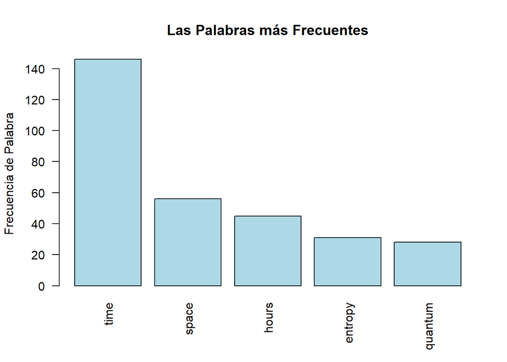

```r
barplot(dm[1:5,]$freq,las=2,names.arg=dm[1:5,]$word,
        col="lightblue",main="Las Palabras más Frecuentes",ylab="Frecuencia de Palabra")
```

Finalmente, se grafica la “WordCloud”

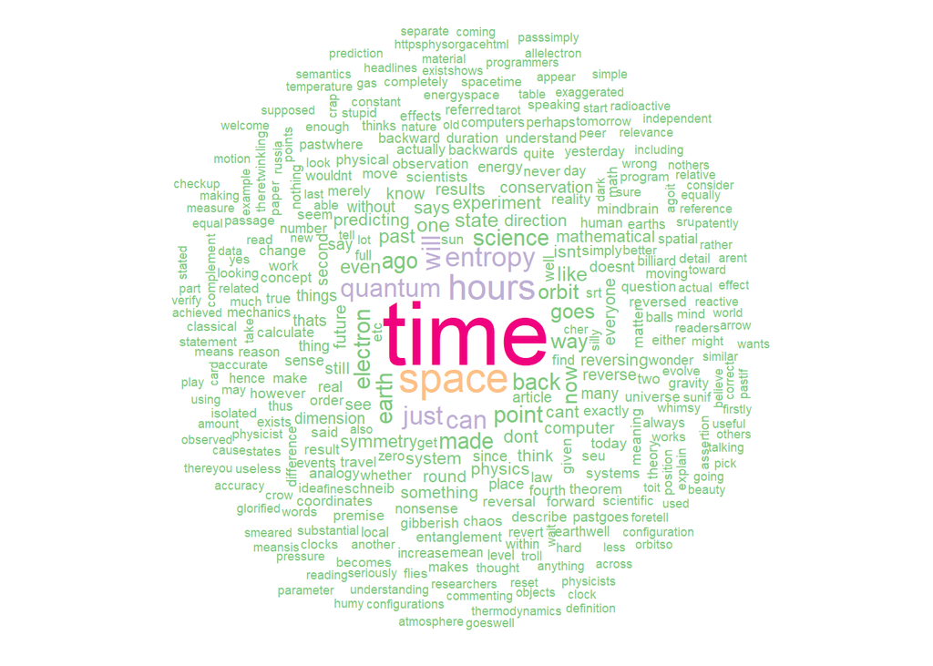

```r
wordcloud(dm$word, dm$freq, random.order=FALSE,colors=brewer.pal(6, "Accent"))
```

El análisis de sentimientos es una herramienta muy útil, sin embargo, se deben tomar en cuenta ciertos aspectos como el mencionado al crearse la categoría “Neutral”, claro que esta es una tarea muy complicada en cuanto más grandes son nuestros datos.